# Use BiDAG-package with user-defined score

Vera Kvisgaard

This note shows how the `BiDAG` package can be manipulated used to learn labeled DAGs.

```r
library(pcalg)
library(BiDAG)

# prep
here::i_am("./rmd/BiDAG_with_user_defined_score.Rmd")
files <- list.files(here::here("R"), ".R", full.names = T)
sapply(files, source)
```

[output not shown]

## Define netowrk with context-specific independencies

Define a Bayesian network over three nodes, a collider structure, where the CPT of the collider node $Y$ contains context-specific independence, labels on the edges pointing into $Y$.

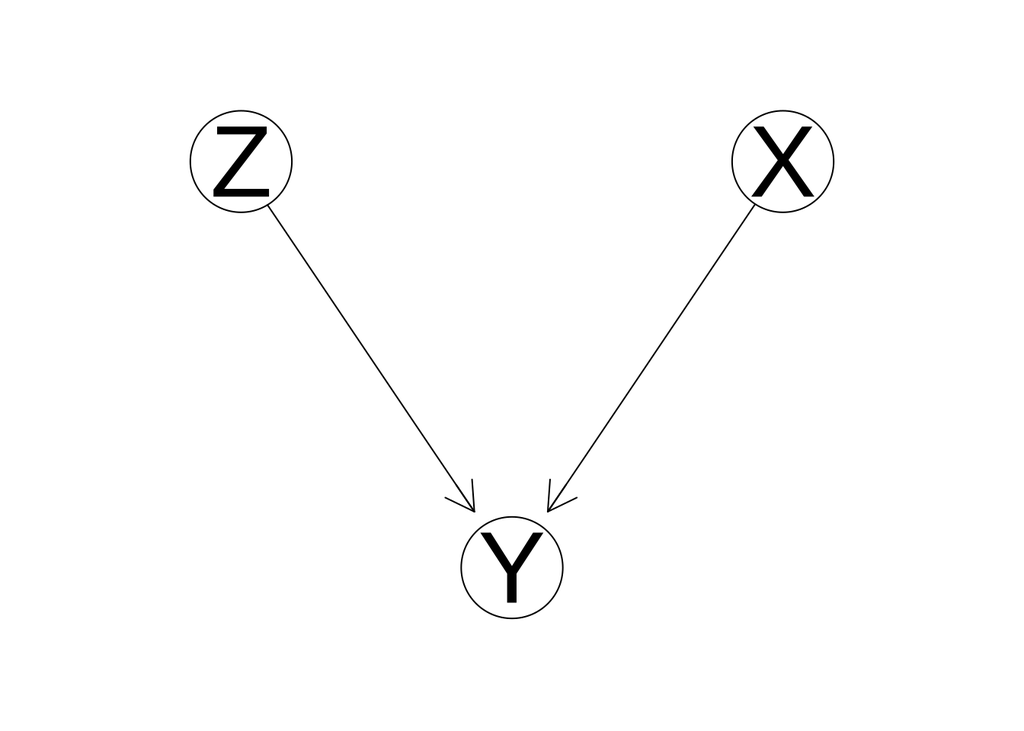

```r
dag <- rbind(Z = c(0, 0, 1),
             X = c(0, 0, 1),
             Y = c(0, 0, 0))
colnames(dag) <- rownames(dag)
Rgraphviz::plot(as(dag, "graphNEL"))
```

The distribution is designed to illustrate when labeled DAGs can help directing edges. With dependendence only in one single context, the direction is the of edges is hard to detect.

```r
cpts <- setNames(vector("list", ncol(dag)), colnames(dag))
levels <- rep(list(0:1), 3)
names(levels) <- names(cpts)
nlev <- lengths(levels)
n <- length(nlev)


cpts$Z <- array(c(.5, .5), 2, levels["Z"])
cpts$X <- array(c(.5, .5), 2, levels[c("X")])

# encode some "weak" context-specific independence
# Y is independent of Z given X = 0 and independent on X given Z = 0
p <- .75
cpts$Y <- array(c(rep(c(p, 1-p), 3), 1-p, p),
                c(2, 2, 2),
                levels[c("Y", "Z", "X")])
cpts
```

```
## $Z
## Z
##   0   1
## 0.5 0.5
##
## $X
## X
##   0   1
## 0.5 0.5
##
## $Y
## , , X = 0
##
##    Z
## Y      0    1
##   0 0.75 0.75
##   1 0.25 0.25
##
## , , X = 1
##
##    Z
## Y      0    1
##   0 0.75 0.25
##   1 0.25 0.75
```

Store as `bn.fit` object and sample data:

```r
g <- bnlearn::empty.graph(names(cpts))
bnlearn::amat(g) <- dag
bn <- bnlearn::custom.fit(g, cpts)

set.seed(007)
df <- bnlearn::rbn(bn, 100)
data <- sapply(df, as.numeric) -1
```

## Compute local scores of LDAGs

Define routine for computing the local score of a LDAG-node:

```r
#' Compute local score in a labeled DAG from data
#'
#' Compute sample counts over the relevant subset of variables and compute score.
#' If more than one parent return the score of the optimal local CSI-structure.
#'
#' @param j node to be scored
#' @param parentsnodes parents of this node
#' @param n number of nodes
#' @param param object of `scoreparameters`
#'
#' @return score of node `j` given `parentnodes` and optimal CSI-structure
local_CSI_score <- function(data, nlev, j, parentnodes, ess = 1, kappa = .1) {

  npar <- length(parentnodes)
  if (npar == 0) {
    r <- nlev[j]
    counts <- matrix(tabulate(data[, j] +1, nlev[j]), ncol = nlev[j])
    famscore_bdeu_byrow(counts, ess, r, 1)
  } else if (npar == 1) {
    r <- nlev[j]
    q <- nlev[parentnodes]
    counts <- tabulate(data[, c(parentnodes, j)]%*%c(1, q) +1, q*r)
    dim(counts) <- c(q, r)
    sum(famscore_bdeu_byrow(counts, ess, r, q))
  } else {

    # optimal CSI-structure
    res <- optimize_CSI_structure(data, nlev, j, parentnodes, ess = ess, kappa = kappa)

    # return penalized score
    r <- nlev[j]
    q <- prod(nlev[parentnodes])
    sum(res$scores) + (q-length(res$partition))*(r-1)*log(kappa)
  }
}
```

### Result of `optimize_CSI_structure`:

The function returns the optimal partition and each parts contribution to the score of the local distribution.

```r
cat("Optimized CSI-structure:\n")
optimize_CSI_structure(data, nlev, 3, 1:2, ess = 1, kappa = .5)
sum(optimize_CSI_structure(data, nlev, 3, 1:2, ess = 1, kappa = .5)$scores)

cat("Full CPT:\n")
optimize_CSI_structure(data, nlev, 3, 1:2, ess = 1, kappa = 0)
sum(optimize_CSI_structure(data, nlev, 3, 1:2, ess = 1, kappa = 0)$scores)
```

```
## Optimized CSI-structure:
## $partition
## $partition[[1]]
## [1] 0 1 2
##
## $partition[[2]]
## [1] 3
##
##
## $scores
##         1         2
## -44.70445 -13.08516
##
## [1] -57.78961
## Full CPT:
## $partition
## $partition[[1]]
## [1] 0
##
## $partition[[2]]
## [1] 1
##
## $partition[[3]]
## [1] 2
##
## $partition[[4]]
## [1] 3
##
##
## $scores
##         1         2         3         4
## -17.11727 -16.48773 -15.71680 -13.08516
##
## [1] -62.40695
```

Check score of node `Y` with different parent sets:

```r
cat("Local scores:\n")
local_CSI_score(data, nlev, 3, integer(0), ess = 1, kappa = .5)
local_CSI_score(data, nlev, 3, 1, ess = 1, kappa = .5)
local_CSI_score(data, nlev, 3, 2, ess = 1, kappa = .5)
local_CSI_score(data, nlev, 3, 1:2, ess = 1, kappa = .5)
```

```
## Local scores:
##         Y
## -67.87284
## [1] -69.31632
## [1] -61.76262
##        Y
## -59.1759
```

Check observed sample proportions

```r
cat("\n observed P(Y|X, Z):\n")
counts <- table(df[, c("Y", "Z", "X")])
counts/rep(colSums(counts), each = 2)
```

```
##
##  observed P(Y|X, Z):
## , , X = 0
##
##    Z
## Y           0         1
##   0 0.7777778 0.8387097
##   1 0.2222222 0.1612903
##
## , , X = 1
##
##    Z
## Y           0         1
##   0 0.6500000 0.1818182
##   1 0.3500000 0.8181818
```

## Run `BiDAG::iterativeMCMC`

Define a `scoreparameters`-object for `BiDAG`’s MCMC functions. Note that the level of each variable is added to the list of parameters. I think this argument is used in the PC-algorithm-step, but it is not added when `type = "usr"`.

```r
library(BiDAG)
scorepar <- scoreparameters("usr",
                         data = data,
                         usrpar = list(pctesttype = "bdecat"))
scorepar$Cvec <- nlev
```

Define the user-specified scoring function that is to be called from `BiDAG`-functions. Also, assign this function to the name-space of `BiDAG`-package, as otherwise an internal function is called.

```r
#' See `scoretype` parameter in [BiDAG::scoreparameters].
usrDAGcorescore <- function(j, parentnodes, n, param) {
  local_CSI_score(param$data, nlev, j, parentnodes, ess = 1, kappa = .5)
}

assignInNamespace("usrDAGcorescore", usrDAGcorescore, ns = "BiDAG")
```

Run iterativeMCMC:

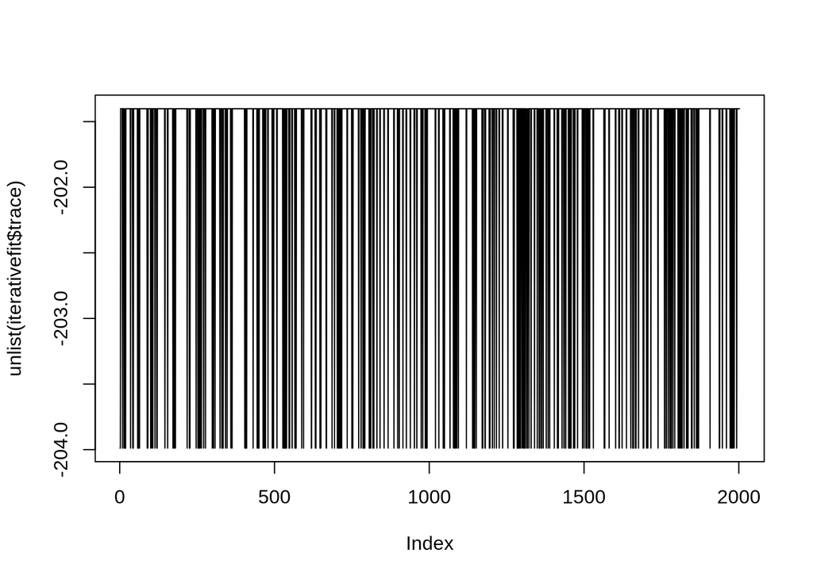

```r
iterativefit <- learnBN(scorepar, algorithm = "orderIter", scoreout = T, verbose = T)
plot(unlist(iterativefit$trace), type = "l")
```

```r
summary(iterativefit)
```

```
## maximum parent set size is 1
## core space defined, score table are being computed
## score tables completed, iterative MCMC is running
## search space expansion 2
## object of class 'iterativeMCMC'
##
## Results:
## maximum score DAG with 3 nodes and  2  edges:
## maximum DAG score= -201.4015
##
## algorithm: iterative order MCMC
## number of search space expansion steps: 2
## number of edges in the intial search space: 2
## number of added edges: 2
## total number of MCMC iterations: 50000
## total number of MCMC sampling steps (length of trace): 2002
## number of MCMC iterations per expansion step: 25000
## number of MCMC sampling steps per expansion step: 1001
## initial search space: PC
## sample/MAP:  MAP
##
## Additional output:
## scoretable, object of class 'scorespace'
```

```r
cat("\n MAP DAG and score")
iterativefit$DAG
iterativefit$score
```

```
##
##  MAP DAG and score3 x 3 sparse Matrix of class "dtCMatrix"
##   Z X Y
## Z . . 1
## X . . 1
## Y . . .
## [1] -201.4015
```

Compare score of MAP-dag with that given by user-defined function:

```r
tmp <- sapply(seq_along(bn),
              function(j) usrDAGcorescore(j, which(iterativefit$DAG[, j] == 1), n = length(bn), scorepar))
all(sum(tmp) == iterativefit$score)
```

```
## [1] TRUE
```

# Repeat using standard BDeu-score

```r
scorepar <- scoreparameters("bdecat",
                         data = df,
                         bdecatpar = list(chi = 1, edgepf = 1))
iterativefit <- learnBN(scorepar, algorithm = "orderIter", scoreout = T, verbose = T)

iterativefit$DAG
iterativefit$score
```

```
## maximum parent set size is 1
## core space defined, score table are being computed
## score tables completed, iterative MCMC is running
## 3 x 3 sparse Matrix of class "dtCMatrix"
##   Z X Y
## Z . . .
## X . . 1
## Y . . .
## [1] -203.9882
```

```r
BiDAG:::DAGcorescore(3, integer(0), 3, scorepar)
BiDAG:::DAGcorescore(3, 1, 3, scorepar)
BiDAG:::DAGcorescore(3, 2, 3, scorepar)
BiDAG:::DAGcorescore(3, 1:2, 3, scorepar)
```

```
##         Y
## -67.87284
##         Z
## -69.31632
##         X
## -61.76262
##         Y
## -62.40695
```